# Stats240P-FinalProject

Linh Trinh

2023-05-30

### Exploring Data set

```r
library(readr)
wine_data <- read_csv("wine-quality-white-and-red.csv")
str(wine_data)
```

```
## spc_tbl_ [6,497 × 13] (S3: spec_tbl_df/tbl_df/tbl/data.frame)
##  $ type                : chr [1:6497] "white" "white" "white" "white" ...
##  $ fixed acidity       : num [1:6497] 7 6.3 8.1 7.2 7.2 8.1 6.2 7 6.3 8.1 ...
##  $ volatile acidity    : num [1:6497] 0.27 0.3 0.28 0.23 0.23 0.28 0.32 0.27 0.3 0.22 ...
##  $ citric acid         : num [1:6497] 0.36 0.34 0.4 0.32 0.32 0.4 0.16 0.36 0.34 0.43 ...
##  $ residual sugar      : num [1:6497] 20.7 1.6 6.9 8.5 8.5 6.9 7 20.7 1.6 1.5 ...
##  $ chlorides           : num [1:6497] 0.045 0.049 0.05 0.058 0.058 0.05 0.045 0.045 0.049 0.044 ...
##  $ free sulfur dioxide : num [1:6497] 45 14 30 47 47 30 30 45 14 28 ...
##  $ total sulfur dioxide: num [1:6497] 170 132 97 186 186 97 136 170 132 129 ...
##  $ density             : num [1:6497] 1.001 0.994 0.995 0.996 0.996 ...
##  $ pH                  : num [1:6497] 3 3.3 3.26 3.19 3.19 3.26 3.18 3 3.3 3.22 ...
##  $ sulphates           : num [1:6497] 0.45 0.49 0.44 0.4 0.4 0.44 0.47 0.45 0.49 0.45 ...
##  $ alcohol             : num [1:6497] 8.8 9.5 10.1 9.9 9.9 10.1 9.6 8.8 9.5 11 ...
##  $ quality             : num [1:6497] 6 6 6 6 6 6 6 6 6 6 ...
##  - attr(*, "spec")=
##   .. cols(
##   ..   type = col_character(),
##   ..   `fixed acidity` = col_double(),
##   ..   `volatile acidity` = col_double(),
##   ..   `citric acid` = col_double(),
##   ..   `residual sugar` = col_double(),
##   ..   chlorides = col_double(),
##   ..   `free sulfur dioxide` = col_double(),
##   ..   `total sulfur dioxide` = col_double(),
##   ..   density = col_double(),
##   ..   pH = col_double(),
##   ..   sulphates = col_double(),
##   ..   alcohol = col_double(),
##   ..   quality = col_double()
##   .. )
##  - attr(*, "problems")=<externalptr>
```

The provided information shows the structure of a dataset with 6497 rows and 13 columns. Here’s a breakdown of the columns:

- type: Character column indicating the type of wine (white or red).
- fixed acidity: Numeric column representing the fixed acidity level of the wine.
- volatile acidity: Numeric column representing the volatile acidity level of the wine.
- citric acid: Numeric column representing the citric acid content in the wine.
- residual sugar: Numeric column indicating the residual sugar content in the wine.
- chlorides: Numeric column representing the chlorides concentration in the wine.
- free sulfur dioxide: Numeric column indicating the concentration of free sulfur dioxide in the wine.
- total sulfur dioxide: Numeric column indicating the total concentration of sulfur dioxide in the wine.
- density: Numeric column representing the density of the wine.
- pH: Numeric column representing the pH value of the wine.
- sulphates: Numeric column indicating the sulphates concentration in the wine.
- alcohol: Numeric column indicating the alcohol content in the wine.
- quality: Numeric column representing the quality score of the wine.

```r
table(wine_data$quality)
```

```
##
##    3    4    5    6    7    8    9
##   30  216 2138 2836 1079  193    5
```

It’s clear from the above table that there is a very big class imbalance. There are 6497 samples but only 30 are of the 3 class and only 5 are of the 9 class.

```r
#checking for missing values before EDA
colSums(is.na(wine_data))
```

```
##                 type        fixed acidity     volatile acidity
##                    0                    0                    0
##          citric acid       residual sugar            chlorides
##                    0                    0                    0
##  free sulfur dioxide total sulfur dioxide              density
##                    0                    0                    0
##                   pH            sulphates              alcohol
##                    0                    0                    0
##              quality
##                    0
```

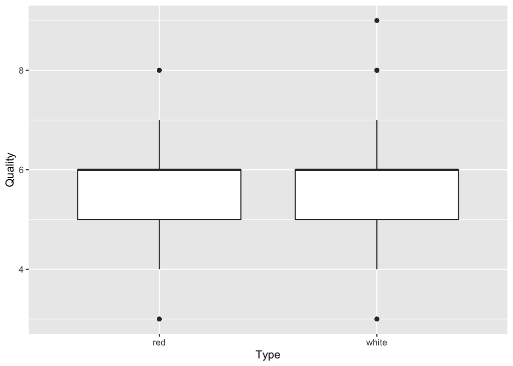

```r
#check boxplot for any outliners
# Install and load necessary libraries
library(tidyverse)
# Boxplot: quality by type
ggplot(wine_data, aes(x = type, y = quality, group = type)) +
  geom_boxplot() +
  labs(x = "Type", y = "Quality")
```

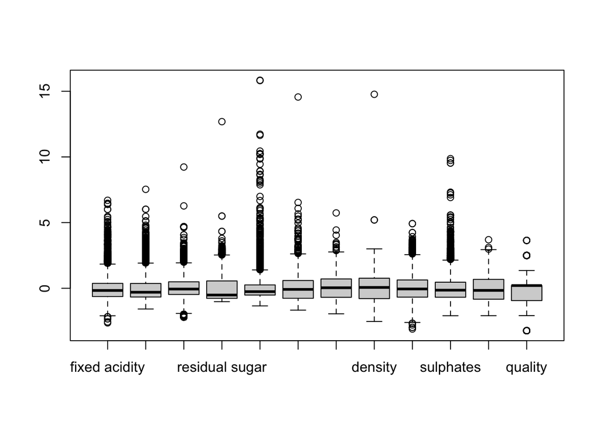

```r
numeric_columns <- wine_data[, sapply(wine_data, is.numeric)]  # Select only numeric columns
# Boxplot: quality by type
boxplot(scale(numeric_columns))
```

```r
numeric_columns <- wine_data[, sapply(wine_data, is.numeric)]  # Select only numeric columns

summary_table <- sapply(numeric_columns, function(x) {
  c(Count = length(x),
    Mean = mean(x, na.rm = TRUE),
    Std = sd(x, na.rm = TRUE),
    Min = min(x, na.rm = TRUE),
    `25%` = quantile(x, 0.25, na.rm = TRUE),
    Median = median(x, na.rm = TRUE),
    `75%` = quantile(x, 0.75, na.rm = TRUE),
    Max = max(x, na.rm = TRUE))
})

# Convert the summary table to data frame
summary_df <- as.data.frame(summary_table)

# Print the summary table
print(summary_df)
```

```
##         fixed acidity volatile acidity  citric acid residual sugar    chlorides
## Count     6497.000000     6497.0000000 6497.0000000    6497.000000 6.497000e+03
## Mean         7.215307        0.3396660    0.3186332       5.443235 5.603386e-02
## Std          1.296434        0.1646365    0.1453179       4.757804 3.503360e-02
## Min          3.800000        0.0800000    0.0000000       0.600000 9.000000e-03
## 25%.25%      6.400000        0.2300000    0.2500000       1.800000 3.800000e-02
## Median       7.000000        0.2900000    0.3100000       3.000000 4.700000e-02
## 75%.75%      7.700000        0.4000000    0.3900000       8.100000 6.500000e-02
## Max         15.900000        1.5800000    1.6600000      65.800000 6.110000e-01
##         free sulfur dioxide total sulfur dioxide      density           pH
## Count            6497.00000           6497.00000 6.497000e+03 6497.0000000
## Mean               30.52532            115.74457 9.946966e-01    3.2185008
## Std                17.74940             56.52185 2.998673e-03    0.1607872
## Min                 1.00000              6.00000 9.871100e-01    2.7200000
## 25%.25%            17.00000             77.00000 9.923400e-01    3.1100000
## Median             29.00000            118.00000 9.948900e-01    3.2100000
## 75%.75%            41.00000            156.00000 9.969900e-01    3.3200000
## Max               289.00000            440.00000 1.038980e+00    4.0100000
##            sulphates     alcohol      quality
## Count   6497.0000000 6497.000000 6497.0000000
## Mean       0.5312683   10.491801    5.8183777
## Std        0.1488059    1.192712    0.8732553
## Min        0.2200000    8.000000    3.0000000
## 25%.25%    0.4300000    9.500000    5.0000000
## Median     0.5100000   10.300000    6.0000000
## 75%.75%    0.6000000   11.300000    6.0000000
## Max        2.0000000   14.900000    9.0000000
```